# wyz.code.rdoc Tutorial

Fabien GELINEAU

Last update 2019.08.27

[figure not shown]

Package wyz.code.rdoc aims to ease manual page creation in a very flexible way. It aims to free you from learning R documentation specific language and its arcanes, while providing good and reliable results in a quick and reproducible way.

# 1 Understanding manual page generation

Manual pages are associated either to describe processing functions or to describe data. Both are important, and each comes with its own specification set.

From a pratical point of view, it exists several ways to produce manual pages. Indeed two are currently the most commonly used. First one is based on handcrafted manual pages. Second one is based on generated manual pages.

## 1.1 Handcrafted manual page

Standard R documentation tools to generate manual pages belongs to the first approach. The global manual page generation process looks like following one.

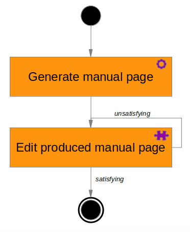

In this is a two steps process, you first generate a manual page template once and only once, and then fill-in the blanks with the desired content.

In practice, you end up repeating a variable number of times the fill-in phase for each manual page. Moreover, it requires you to get acknowledge about R documentation arcanes, and this is quite complex due to syntax issues, character escaping and some other not so simple to fulfil needs.

## 1.2 roxygen2 generated manual page

Package roxygen2 meets the second approach. Its manual page generation process looks like following one

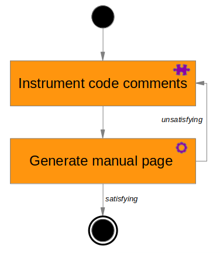

Theoritically, this is a two steps process, where you first fill-in the code comments according to roxygen2 specification, and then generate on-demand the related manual pages. This is a much more industrial approach.

In practice, compliance with code comments specification is not so easy and still requires deep understanding of R documentation scheme. Manual page generation although robust and fast, may sometimes be cumbersome.

## 1.3 wyz.code.rdoc generated manual page

Package wyz.code.rdoc meets the already presentend second approach. Its manual page generation process looks like following one.

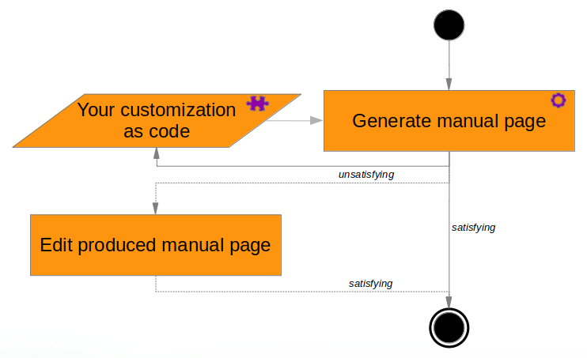

Theoritically, this is a three steps process

1. create your manual page customization
2. generate the related manual page
3. edit the resulting manual page

In practice, this is often a two steps process, as editing resulting manual page is an optional step, only required when the cost of the modification is higher to be achieved by code than by hand.